# Coding Assessment 3

Author

Ben Sunshine

Question 1 (30 points). In the handwritten portion of the quiz, you were asked to make a sketch of a visualization you would make to interpret a model with lego price as the response and pieces (quantitative), theme (categorical with 3 levels: “City”, “DUPLO®”, “Friends”), age_5 (categorical with 2 levels: “no”, “yes”), and the interaction between pieces and theme as predictors. Using the lego_df data set, construct the plot given below.

```r
library(tidyverse)
library(broom)
library(modelr)
lego_df <- read_csv(here::here("data/lego_sample.csv")) |>
  mutate(age_5 = if_else(ages %in% c("Ages_6-12", "Ages_6+",
                                     "Ages_7+", "Ages_8+"),
                                  true = "no", false = "yes"))
```

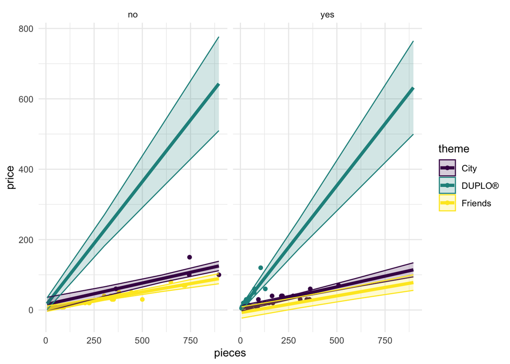

```r
library(broom)
lm_price <- lm(price ~ pieces + theme + age_5 + pieces:theme, data = lego_df)

grid <- lego_df |>
  data_grid(
    # trim() trims the ages at each tail by (0.1/2) * length(x)
    pieces = seq_range(pieces, n = 4),
    theme = c("City", "DUPLO®", "Friends"),
    age_5 = c("no", "yes")
  )

aug <- augment(lm_price, newdata = grid, interval = "confidence")

aug %>%
  ggplot(aes(x = pieces,
             y = .fitted,
             color = theme)) +
  geom_point(data = lego_df, aes(x = pieces, y = price),
             #alpha = 0.3
             ) +

  geom_line(aes(color = as.factor(theme)),
            linewidth = 1.5) +
  geom_ribbon(data = aug, aes(y = .fitted,
                              ymin = .lower,
                              ymax = .upper,
                              fill = theme),
              alpha = 0.2
              # couldn't get the outlines in the ribbon to disappear:
              # tried "both", "upper", "lower", and "full"
              #, outline.type = "both"
              ) +
  scale_color_viridis_d() +
  scale_fill_viridis_d() +
  facet_wrap(~ age_5) +
  theme_minimal() +
  labs(color = "theme",
       x = "pieces",
       y = "price")
```

Question 2 (2 points). For the model fit above (with pieces (quantitative), theme (categorical with 3 levels: “City”, “DUPLO®”, “Friends”), age_5 (categorical with 2 levels: “no”, “yes”), and the interaction between pieces and theme as predictors), use tidy() to create a summary table of output of the model.

```r
lm_price %>% tidy()
```

```
# A tibble: 7 × 5
  term                estimate std.error statistic  p.value
  <chr>                  <dbl>     <dbl>     <dbl>    <dbl>
1 (Intercept)          15.5       9.99       1.55  1.25e- 1
2 pieces                0.122     0.0142     8.59  1.89e-12
3 themeDUPLO®          -1.97      5.26      -0.375 7.09e- 1
4 themeFriends        -12.1      10.1       -1.21  2.31e- 1
5 age_5yes            -11.0       7.82      -1.40  1.66e- 1
6 pieces:themeDUPLO®    0.580     0.0783     7.41  2.63e-10
7 pieces:themeFriends  -0.0268    0.0172    -1.56  1.24e- 1
```

Question 3 (2 points). For the model fit above, use glance() to obtain some basic model statistics.

```r
lm_price %>% glance()
```

```
# A tibble: 1 × 12
  r.squared adj.r.squared sigma statistic  p.value    df logLik   AIC   BIC
      <dbl>         <dbl> <dbl>     <dbl>    <dbl> <dbl>  <dbl> <dbl> <dbl>
1     0.842         0.828  11.5      60.3 2.68e-25     6  -286.  588.  607.
# ℹ 3 more variables: deviance <dbl>, df.residual <int>, nobs <int>
```

Question 4 (6 points). For the model fit above, use augment() to create a data frame with fitted values, residuals, leverage, cook’s distance, etc. Then, use this data frame to construct a residual plot (a plot of the model residuals vs. the fitted values).

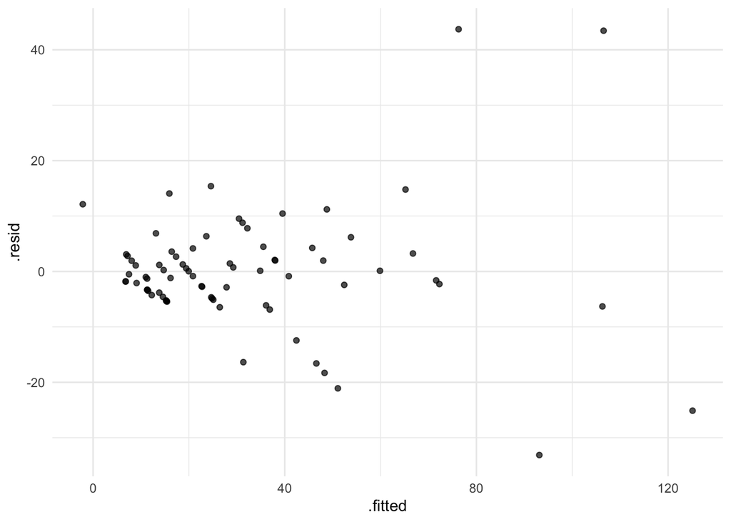

```r
augment(lm_price) %>%
  ggplot(aes(x = .fitted, y = .resid)) +
  geom_jitter(alpha = 0.7) +
  theme_minimal()
```